# Finance Crisis in 2016 Project

### Disclaimer

1. This Capstone Project is specially designed for Hacctech's **Data Science with Python** program (DSP2105) serving the purpose of examining how great the student is in terms of mastering the Data Analytics, such that laying a solid foundation for future careers.
2. The datasets are from the Internet, and modified by the Course Designer to serve the purpose better. such modification / tuning doesn't alter the copyrights (if any), nor the ownership of the datasets.

**Course Designer**: Marcus Zou

## 1- Project background

In this data project we will focus on exploratory data analysis (EDA) of stock prices of some banks.

We'll focus on bank stocks and see how they progressed throughout the [financial crisis](https://en.wikipedia.org/wiki/Financial_crisis_of_2007%E2%80%9308) all the way to early 2016.

## 2- Install packages in Anaconda

We assume you have installed those regular packages in Anaconda, such as `numpy`, `scipy`, `pandas`, `matplotlib`, `seaborn`, etc. but the special packages for stock prices, "`pandas_datareader`" and "`cufflinks`" libraries, may not be installed in Anaconda by default.

1. Install `pandas_datareader` package
- Open "`Anaconda Navigator`", click "`Environments`", select "`base (root)`";
- Type in "`pandas_datareader`" in the "`Search Packages`" box while ensuring Channels stay at "`All`" or "`Not Installed`";
- Check the box of "`pandas_datareader`" and click "`Apply`" to install.
1. Install `cufflinks` package
- Open "`Anaconda Prompt`";
- Type in the following command to install cufflinks:

  `conda install -c conda-forge cufflinks-py`
- Type in "`Y`" or "`yes`" when prompted.

## 3- Getting the Data

```python
from pandas_datareader import data, wb
import pandas as pd
import numpy as np
import datetime
import matplotlib.pyplot as plt
%matplotlib inline
import seaborn as sns
```

### Data

We need to get data using pandas_datareader. And we will get stock information for the following banks:

- Bank of America
- CitiGroup
- Goldman Sachs
- JPMorgan Chase
- Morgan Stanley
- Wells Fargo

**Figuring out how to get the stock data from Jan 1st 2006 to Jan 1st 2016 for each of these banks. Setting each bank to be a separate dataframe, with the variable name for that bank being its ticker symbol. This involved a few steps:**

1. Use datetime to set start and end datetime objects.
2. Figure out the ticker symbol for each bank.
3. Figure out how to use pandas_datareader to grab info on the stock.

**Use [this documentation page](https://pandas-datareader.readthedocs.io/en/latest/remote_data.html) for hints and instructions.**

```
# Bank of America
BAC = data.DataReader("BAC", 'google', start, end)
```

```python
start = datetime.datetime(2006,1,1)
end = datetime.datetime(2016,1,1)
```

```python
# Bank of America
BAC = data.DataReader('BAC',start='2006, 1, 1',end='2016, 1, 1',data_source='yahoo')
BAC.head()
```

| Date | High | Low | Open | Close | Volume | Adj Close |
| --- | --- | --- | --- | --- | --- | --- |
| 2006-01-03 | 47.180000 | 46.150002 | 46.919998 | 47.080002 | 16296700.0 | 34.280807 |
| 2006-01-04 | 47.240002 | 46.450001 | 47.000000 | 46.580002 | 17757900.0 | 33.916729 |
| 2006-01-05 | 46.830002 | 46.320000 | 46.580002 | 46.639999 | 14970700.0 | 33.960411 |
| 2006-01-06 | 46.910000 | 46.349998 | 46.799999 | 46.570000 | 12599800.0 | 33.909451 |
| 2006-01-09 | 46.970001 | 46.360001 | 46.720001 | 46.599998 | 15619400.0 | 33.931290 |

```python
# Citi Group
C = data.DataReader('C',start='2006, 1, 1', end='2016, 1, 1',data_source='yahoo')

# Goldman Sachs
GS = data.DataReader('GS',start='2006, 1, 1', end='2016, 1, 1',data_source='yahoo')

# JPMorgan Chase
JPM = data.DataReader('JPM',start='2006, 1, 1', end='2016, 1, 1',data_source='yahoo')

# Morgan Stanley
MS = data.DataReader('MS',start='2006, 1, 1', end='2016, 1, 1',data_source='yahoo')

# Wells Fargo
WFC = data.DataReader('WFC',start='2006, 1, 1', end='2016, 1, 1',data_source='yahoo')
```

```python
MS
```

| Date | High | Low | Open | Close | Volume | Adj Close |
| --- | --- | --- | --- | --- | --- | --- |
| 2006-01-03 | 58.490002 | 56.740002 | 57.169998 | 58.310001 | 5377000.0 | 36.631054 |
| 2006-01-04 | 59.279999 | 58.349998 | 58.700001 | 58.349998 | 7977800.0 | 36.656166 |
| 2006-01-05 | 58.590000 | 58.020000 | 58.549999 | 58.509998 | 5778000.0 | 36.756695 |
| 2006-01-06 | 58.849998 | 58.049999 | 58.770000 | 58.570000 | 6889800.0 | 36.794384 |
| 2006-01-09 | 59.290001 | 58.619999 | 58.630001 | 59.189999 | 4144500.0 | 37.183868 |
| ... | ... | ... | ... | ... | ... | ... |
| 2015-12-24 | 32.709999 | 32.439999 | 32.570000 | 32.480000 | 2798200.0 | 28.434517 |
| 2015-12-28 | 32.360001 | 31.950001 | 32.360001 | 32.169998 | 5420300.0 | 28.163136 |
| 2015-12-29 | 32.700001 | 32.330002 | 32.439999 | 32.549999 | 6388200.0 | 28.495804 |
| 2015-12-30 | 32.650002 | 32.200001 | 32.500000 | 32.230000 | 5057200.0 | 28.215654 |
| 2015-12-31 | 32.299999 | 31.770000 | 31.910000 | 31.809999 | 8154300.0 | 27.847975 |

2517 rows × 6 columns

### 4- Data Wrangling a bit

Creating a list of the ticker symbols (as strings) in alphabetical order. Call this list: `tickers`.

```python
tickers = ['BAC','C','GS','JPM','MS','WFC']
```

**Using pd.concat function to concatenate the bank dataframes together to a single data frame called `bank_stocks`. Setting the `keys` argument equal to the `tickers` list.**

```python
bank_stocks = pd.concat([BAC,C,GS,JPM,MS,WFC], axis = 1, keys = tickers)
```

```python
# take a look at the new table
bank_stocks
```

| Date | BAC High | BAC Low | BAC Open | BAC Close | BAC Volume | BAC Adj Close | C High | C Low | C Open | C Close | ... | MS Open | MS Close | MS Volume | MS Adj Close | WFC High | WFC Low | WFC Open | WFC Close | WFC Volume | WFC Adj Close |
| --- | --- | --- | --- | --- | --- | --- | --- | --- | --- | --- | --- | --- | --- | --- | --- | --- | --- | --- | --- | --- | --- |
| 2006-01-03 | 47.180000 | 46.150002 | 46.919998 | 47.080002 | 16296700.0 | 34.280807 | 493.799988 | 481.100006 | 490.000000 | 492.899994 | ... | 57.169998 | 58.310001 | 5377000.0 | 36.631054 | 31.975000 | 31.195000 | 31.600000 | 31.900000 | 11016400.0 | 20.613142 |
| 2006-01-04 | 47.240002 | 46.450001 | 47.000000 | 46.580002 | 17757900.0 | 33.916729 | 491.000000 | 483.500000 | 488.600006 | 483.799988 | ... | 58.700001 | 58.349998 | 7977800.0 | 36.656166 | 31.820000 | 31.365000 | 31.799999 | 31.530001 | 10870000.0 | 20.374050 |
| 2006-01-05 | 46.830002 | 46.320000 | 46.580002 | 46.639999 | 14970700.0 | 33.960411 | 487.799988 | 484.000000 | 484.399994 | 486.200012 | ... | 58.549999 | 58.509998 | 5778000.0 | 36.756695 | 31.555000 | 31.309999 | 31.500000 | 31.495001 | 10158000.0 | 20.351437 |
| 2006-01-06 | 46.910000 | 46.349998 | 46.799999 | 46.570000 | 12599800.0 | 33.909451 | 489.000000 | 482.000000 | 488.799988 | 486.200012 | ... | 58.770000 | 58.570000 | 6889800.0 | 36.794384 | 31.775000 | 31.385000 | 31.580000 | 31.680000 | 8403800.0 | 20.470978 |
| 2006-01-09 | 46.970001 | 46.360001 | 46.720001 | 46.599998 | 15619400.0 | 33.931290 | 487.399994 | 483.000000 | 486.000000 | 483.899994 | ... | 58.630001 | 59.189999 | 4144500.0 | 37.183868 | 31.825001 | 31.555000 | 31.674999 | 31.674999 | 5619600.0 | 20.467749 |
| ... | ... | ... | ... | ... | ... | ... | ... | ... | ... | ... | ... | ... | ... | ... | ... | ... | ... | ... | ... | ... | ... |
| 2015-12-24 | 17.379999 | 17.219999 | 17.320000 | 17.270000 | 29369400.0 | 15.509130 | 52.970001 | 52.450001 | 52.480000 | 52.709999 | ... | 32.570000 | 32.480000 | 2798200.0 | 28.434517 | 55.090000 | 54.709999 | 54.970001 | 54.820000 | 4999400.0 | 46.133739 |
| 2015-12-28 | 17.230000 | 16.980000 | 17.219999 | 17.129999 | 41777500.0 | 15.383405 | 52.570000 | 51.959999 | 52.570000 | 52.380001 | ... | 32.360001 | 32.169998 | 5420300.0 | 28.163136 | 54.779999 | 54.169998 | 54.549999 | 54.680000 | 8288800.0 | 46.015930 |
| 2015-12-29 | 17.350000 | 17.160000 | 17.250000 | 17.280001 | 45670400.0 | 15.518112 | 53.220001 | 52.740002 | 52.759998 | 52.980000 | ... | 32.439999 | 32.549999 | 6388200.0 | 28.495804 | 55.349998 | 54.990002 | 55.110001 | 55.290001 | 7894900.0 | 46.529282 |
| 2015-12-30 | 17.240000 | 17.040001 | 17.200001 | 17.049999 | 35066400.0 | 15.311558 | 52.939999 | 52.250000 | 52.840000 | 52.299999 | ... | 32.500000 | 32.230000 | 5057200.0 | 28.215654 | 55.310001 | 54.790001 | 55.270000 | 54.889999 | 8016900.0 | 46.192661 |
| 2015-12-31 | 17.070000 | 16.830000 | 17.010000 | 16.830000 | 47153000.0 | 15.113990 | 52.389999 | 51.750000 | 52.070000 | 51.750000 | ... | 31.910000 | 31.809999 | 8154300.0 | 27.847975 | 54.950001 | 54.220001 | 54.509998 | 54.360001 | 10929800.0 | 45.746639 |

2517 rows × 36 columns

**Setting the column name levels :**

```python
bank_stocks.columns.names = ['Bank Ticker','Stock Info']
```

```python
bank_stocks.head()
```

| Bank Ticker Stock Info Date | BAC High | BAC Low | BAC Open | BAC Close | BAC Volume | BAC Adj Close | C High | C Low | C Open | C Close | ... | MS Open | MS Close | MS Volume | MS Adj Close | WFC High | WFC Low | WFC Open | WFC Close | WFC Volume | WFC Adj Close |
| --- | --- | --- | --- | --- | --- | --- | --- | --- | --- | --- | --- | --- | --- | --- | --- | --- | --- | --- | --- | --- | --- |
| 2006-01-03 | 47.180000 | 46.150002 | 46.919998 | 47.080002 | 16296700.0 | 34.280807 | 493.799988 | 481.100006 | 490.000000 | 492.899994 | ... | 57.169998 | 58.310001 | 5377000.0 | 36.631054 | 31.975000 | 31.195000 | 31.600000 | 31.900000 | 11016400.0 | 20.613142 |
| 2006-01-04 | 47.240002 | 46.450001 | 47.000000 | 46.580002 | 17757900.0 | 33.916729 | 491.000000 | 483.500000 | 488.600006 | 483.799988 | ... | 58.700001 | 58.349998 | 7977800.0 | 36.656166 | 31.820000 | 31.365000 | 31.799999 | 31.530001 | 10870000.0 | 20.374050 |
| 2006-01-05 | 46.830002 | 46.320000 | 46.580002 | 46.639999 | 14970700.0 | 33.960411 | 487.799988 | 484.000000 | 484.399994 | 486.200012 | ... | 58.549999 | 58.509998 | 5778000.0 | 36.756695 | 31.555000 | 31.309999 | 31.500000 | 31.495001 | 10158000.0 | 20.351437 |
| 2006-01-06 | 46.910000 | 46.349998 | 46.799999 | 46.570000 | 12599800.0 | 33.909451 | 489.000000 | 482.000000 | 488.799988 | 486.200012 | ... | 58.770000 | 58.570000 | 6889800.0 | 36.794384 | 31.775000 | 31.385000 | 31.580000 | 31.680000 | 8403800.0 | 20.470978 |
| 2006-01-09 | 46.970001 | 46.360001 | 46.720001 | 46.599998 | 15619400.0 | 33.931290 | 487.399994 | 483.000000 | 486.000000 | 483.899994 | ... | 58.630001 | 59.189999 | 4144500.0 | 37.183868 | 31.825001 | 31.555000 | 31.674999 | 31.674999 | 5619600.0 | 20.467749 |

5 rows × 36 columns

### 5- Explotary Data Analysis

**What is the max Close price for each bank's stock throughout the time period?**

```python
print("ticker\t Max Close Price")
for ticker in tickers:
    print(ticker, "\t", bank_stocks[ticker]['Close'].max())
```

```
ticker	 Max Close Price
BAC 	 54.900001525878906
C 	 564.0999755859375
GS 	 247.9199981689453
JPM 	 70.08000183105469
MS 	 89.30000305175781
WFC 	 58.52000045776367
```

```python
bank_stocks.xs(key = 'Close', axis = 1, level = 'Stock Info').max()
```

```
Bank Ticker
BAC     54.900002
C      564.099976
GS     247.919998
JPM     70.080002
MS      89.300003
WFC     58.520000
dtype: float64
```

**Creating a new empty DataFrame called `returns`. This dataframe will contain the returns for each bank's stock. `returns` are typically defined by:**

$$r_t = \frac{p_t - p_{t-1}}{p_{t-1}} = \frac{p_t}{p_{t-1}} - 1$$

```python
returns = pd.DataFrame()
```

**Using pandas pct_change() method on the Close column to create a column representing this return value. Creating a for loop that goes and for each Bank Stock Ticker creates this returns column and set's it as a column in the returns DataFrame.**

```python
for ticker in tickers:
    returns[ticker + ' Return'] = bank_stocks[ticker]['Close'].pct_change()
```

```python
returns.head()
```

| Date | BAC Return | C Return | GS Return | JPM Return | MS Return | WFC Return |
| --- | --- | --- | --- | --- | --- | --- |
| 2006-01-03 | NaN | NaN | NaN | NaN | NaN | NaN |
| 2006-01-04 | -0.010620 | -0.018462 | -0.013812 | -0.014183 | 0.000686 | -0.011599 |
| 2006-01-05 | 0.001288 | 0.004961 | -0.000393 | 0.003029 | 0.002742 | -0.001110 |
| 2006-01-06 | -0.001501 | 0.000000 | 0.014169 | 0.007046 | 0.001025 | 0.005874 |
| 2006-01-09 | 0.000644 | -0.004731 | 0.012030 | 0.016242 | 0.010586 | -0.000158 |

**Creating a `pairplot` using `seaborn` of the `returns` dataframe. What stock stands out?**

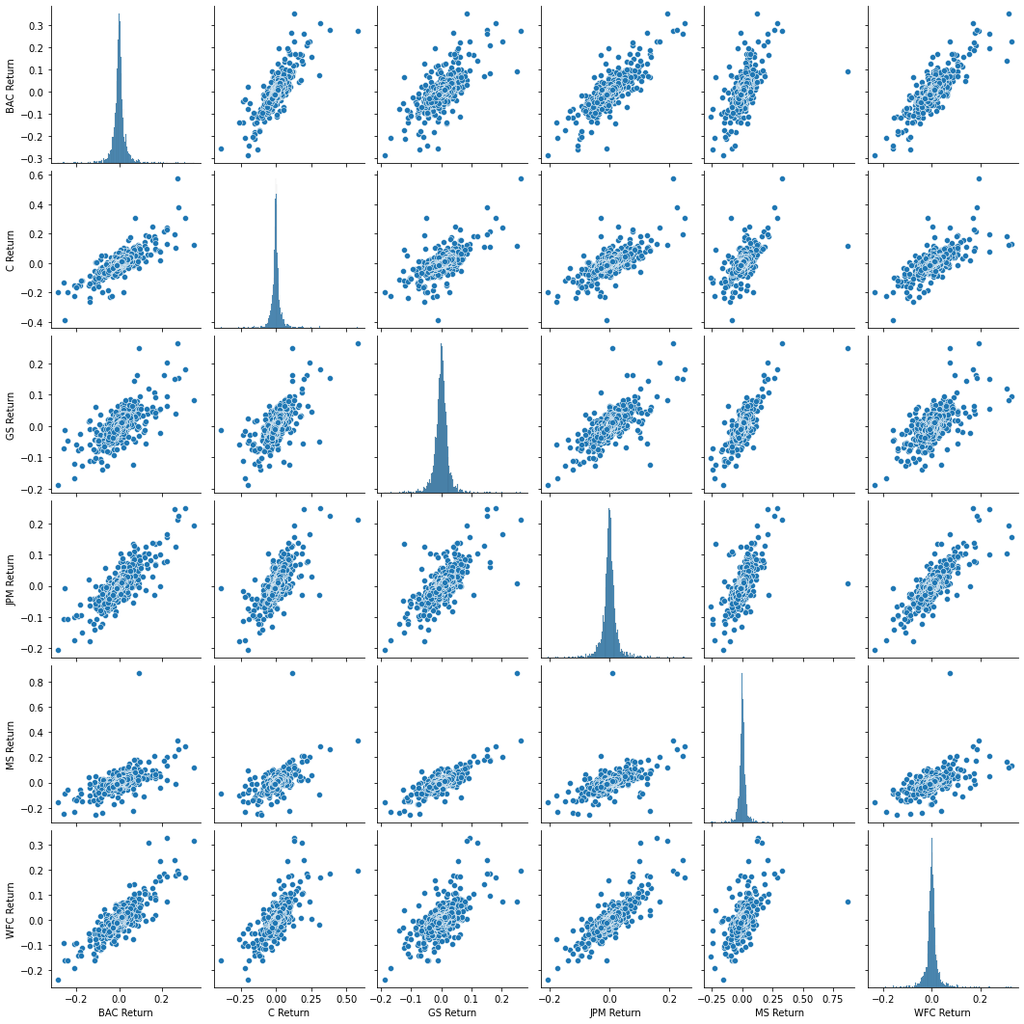

```python
sns.pairplot(returns[1:])
```

**Using this returns DataFrame, figure out on what dates each bank stock had the best and worst single day returns. Notice that 4 of the banks share the same day for the worst drop, did anything significant happen that day?**

```python
returns.min()
```

```
BAC Return   -0.289694
C Return     -0.390244
GS Return    -0.189596
JPM Return   -0.207274
MS Return    -0.258929
WFC Return   -0.238223
dtype: float64
```

```python
returns.idxmin()
```

```
BAC Return   2009-01-20
C Return     2009-02-27
GS Return    2009-01-20
JPM Return   2009-01-20
MS Return    2008-10-09
WFC Return   2009-01-20
dtype: datetime64[ns]
```

```python
returns.idxmax()
```

```
BAC Return   2009-04-09
C Return     2008-11-24
GS Return    2008-11-24
JPM Return   2009-01-21
MS Return    2008-10-13
WFC Return   2008-07-16
dtype: datetime64[ns]
```

On **January 20, 2009** *Barack Obama* takes the oath of office as the 44th president of the United States.

**Taking a look at the standard deviation of the returns, which stock would be classified as the riskiest over the entire time period?**

```python
returns.std()
```

```
BAC Return    0.036647
C Return      0.038672
GS Return     0.025390
JPM Return    0.027667
MS Return     0.037819
WFC Return    0.030238
dtype: float64
```

**Which would be classified as the riskiest for the year 2015?**

```python
returns.loc['2015-01-01':'2015-12-31'].std()
```

```
BAC Return    0.016163
C Return      0.015289
GS Return     0.014046
JPM Return    0.014017
MS Return     0.016249
WFC Return    0.012591
dtype: float64
```

**Creating a `distplot` using `seaborn` of the 2015 returns**

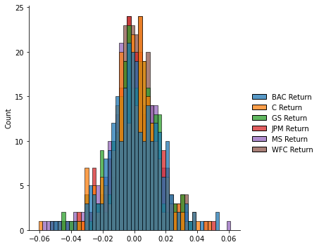

```python
sns.displot(returns.loc['2015-01-01':'2015-12-31'],color = 'green',bins =50)
```

**Creating a `distplot` using `seaborn` of the 2015 returns for Morgan Stanley**

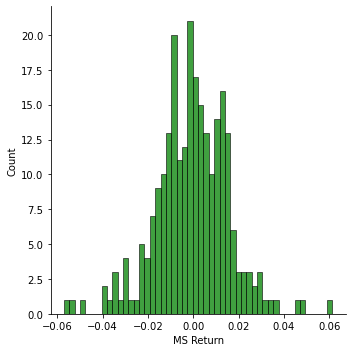

```python
sns.displot(returns.loc['2015-01-01':'2015-12-31']['MS Return'],color = 'green',bins =50)
```

**Creating a `histplot` using `seaborn` of the 2008 returns**

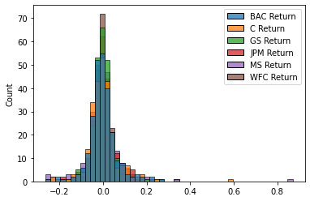

```python
sns.histplot(returns.loc['2008-01-01':'2008-12-31'], bins = 50)
```

**Creating a `histplot` using `seaborn` of the 2008 returns for CitiGroup**

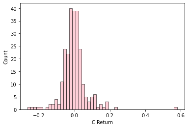

```python
sns.histplot(returns.loc['2008-01-01':'2008-12-31']['C Return'],color='pink', bins = 50)
```

## 6- More Visualization

```python
import matplotlib.pyplot as plt
%matplotlib inline

import seaborn as sns
sns.set_style('whitegrid')

# Plotly Method Imports
import plotly
import cufflinks as cf
cf.go_offline()
```

**Creating a line plot showing Close price for each bank for the entire index of time.**

(Hint: Try using a for loop, or use [.xs](http://pandas.pydata.org/pandas-docs/stable/generated/pandas.DataFrame.xs.html) to get a cross section of the data.)**

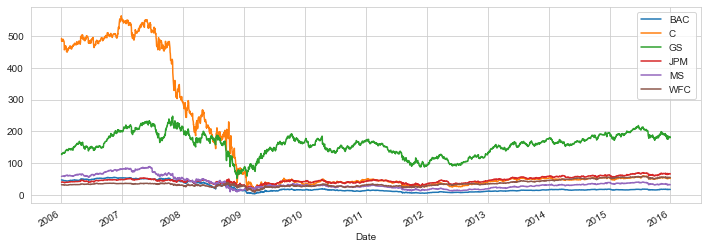

```python
# Using loop

for ticker in tickers:
    bank_stocks[ticker]['Close'].plot(label = ticker, figsize=(12,4))

plt.legend()
```

```python
bank_stocks.xs(key='Close', axis=1, level = 'Stock Info')
```

| Bank Ticker Date | BAC | C | GS | JPM | MS | WFC |
| --- | --- | --- | --- | --- | --- | --- |
| 2006-01-03 | 47.080002 | 492.899994 | 128.869995 | 40.189999 | 58.310001 | 31.900000 |
| 2006-01-04 | 46.580002 | 483.799988 | 127.089996 | 39.619999 | 58.349998 | 31.530001 |
| 2006-01-05 | 46.639999 | 486.200012 | 127.040001 | 39.740002 | 58.509998 | 31.495001 |
| 2006-01-06 | 46.570000 | 486.200012 | 128.839996 | 40.020000 | 58.570000 | 31.680000 |
| 2006-01-09 | 46.599998 | 483.899994 | 130.389999 | 40.669998 | 59.189999 | 31.674999 |
| ... | ... | ... | ... | ... | ... | ... |
| 2015-12-24 | 17.270000 | 52.709999 | 182.470001 | 66.599998 | 32.480000 | 54.820000 |
| 2015-12-28 | 17.129999 | 52.380001 | 181.619995 | 66.379997 | 32.169998 | 54.680000 |
| 2015-12-29 | 17.280001 | 52.980000 | 183.529999 | 67.070000 | 32.549999 | 55.290001 |
| 2015-12-30 | 17.049999 | 52.299999 | 182.009995 | 66.589996 | 32.230000 | 54.889999 |
| 2015-12-31 | 16.830000 | 51.750000 | 180.229996 | 66.029999 | 31.809999 | 54.360001 |

2517 rows × 6 columns

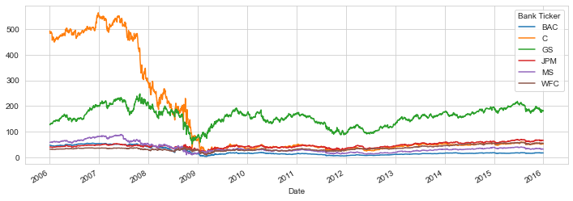

```python
# Using xs

bank_stocks.xs(key='Close', axis=1, level = 'Stock Info').plot(figsize=(12,4))
```

### With cufflinks

```python
bank_stocks.xs(key='Close', axis=1, level = 'Stock Info').iplot()
```

[interactive chart not shown]

## 7- Moving Averages

Analyzing the moving averages for these stocks in the year 2008.

**Plot the rolling 30 day average against the Close Price for Bank Of America's stock for the year 2008**

```python
BAC.head()
```

| Date | High | Low | Open | Close | Volume | Adj Close |
| --- | --- | --- | --- | --- | --- | --- |
| 2006-01-03 | 47.180000 | 46.150002 | 46.919998 | 47.080002 | 16296700.0 | 34.280807 |
| 2006-01-04 | 47.240002 | 46.450001 | 47.000000 | 46.580002 | 17757900.0 | 33.916729 |
| 2006-01-05 | 46.830002 | 46.320000 | 46.580002 | 46.639999 | 14970700.0 | 33.960411 |
| 2006-01-06 | 46.910000 | 46.349998 | 46.799999 | 46.570000 | 12599800.0 | 33.909451 |
| 2006-01-09 | 46.970001 | 46.360001 | 46.720001 | 46.599998 | 15619400.0 | 33.931290 |

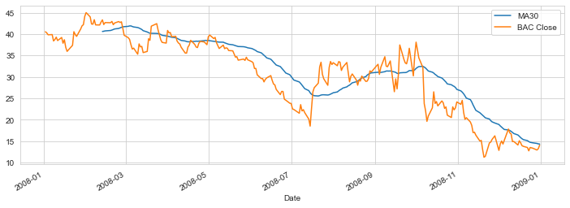

```python
plt.figure(figsize=(12,4))
BAC['Close'].loc['2008-01-01':'2009-01-01'].rolling(window=30).mean().plot(label = 'MA30')
BAC['Close'].loc['2008-01-01':'2009-01-01'].plot(label = 'BAC Close')
plt.legend()
```

**Creating a `heatma`p of the correlation between the stocks Close Price.**

```python
bank_stocks.xs(key = 'Close', axis=1, level='Stock Info').corr()
```

| Bank Ticker | BAC | C | GS | JPM | MS | WFC |
| --- | --- | --- | --- | --- | --- | --- |
| BAC | 1.000000 | 0.971516 | 0.550898 | 0.103874 | 0.944218 | 0.008542 |
| C | 0.971516 | 1.000000 | 0.434123 | 0.003515 | 0.933609 | -0.068536 |
| GS | 0.550898 | 0.434123 | 1.000000 | 0.685286 | 0.683792 | 0.499897 |
| JPM | 0.103874 | 0.003515 | 0.685286 | 1.000000 | 0.250427 | 0.940269 |
| MS | 0.944218 | 0.933609 | 0.683792 | 0.250427 | 1.000000 | 0.131835 |
| WFC | 0.008542 | -0.068536 | 0.499897 | 0.940269 | 0.131835 | 1.000000 |

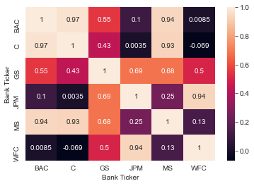

```python
sns.heatmap(bank_stocks.xs(key = 'Close', axis=1, level='Stock Info').corr(), annot = True)
```

**Using seaborn's `clustermap` to cluster the correlations together:**

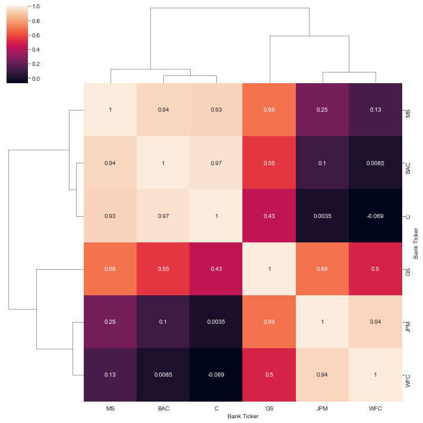

```python
sns.clustermap(bank_stocks.xs(key = 'Close', axis=1, level='Stock Info').corr(), annot = True)
```

## 8- More cufflinks Plotting

In this part of the project, We will rely on the `cufflink`s library to create some `Technical Analysis` plots. This part of the project is experimental due to its heavy reliance on the `cuffinks` project.

**Using `.iplot(kind='candle')` to create a candle plot of Bank of America's stock from Jan 1st 2015 to Jan 1st 2016.**

```python
bac15 = BAC[['Open','High','Low','Close']].loc['2015-01-01':'2016-01-01']
bac15.iplot(kind = 'candle')
```

[interactive chart not shown]

**Using `.ta_plot(study='sma')` to create a `Simple Moving Averages` plot of Morgan Stanley for the year 2015.**

```python
MS['Close'].loc['2015-01-01':'2016-01-01'].ta_plot(study = 'sma', periods =[13,21,55])
```

[interactive chart not shown]

**Using `.ta_plot(study='boll')` to create a `Bollinger Band` Plot for Bank of America for the year 2015.**

```python
BAC['Close'].loc['2015-01-01':'2016-01-01'].ta_plot(study = 'boll', periods =[13,21,55])
```

[interactive chart not shown]

## 9- Conclusions

1. pandas_datareader is a great tool to read stock price.
2. cufflinks is dramatically powerful tool to show case and analyse the stock price and perform business intelligence.